# Assignment 2 - Testing machine learning models for predicting participation in public demonstrations in the last 12 months

17.06.2023

```r
library(ggplot2)
library(rsample)
library(dplyr)
library(caret)
library(e1071)
library(pROC)
library(ROSE)
library(yardstick)
library(ROCR)
library(tidyverse)
comment=NA
```

# 1. Data Pre-processing

We import data set.

```r
data <- read.csv('/Users/akakikuprashvili/Desktop/Big Data/ESS9e03_1-4/ESS9e03_1.csv')
comment=NA
```

```r
selected_columns_1 <- data %>%
  filter(cntry %in% c('BG', 'AT', 'DE', 'GB', 'IT', 'IE')) %>%
  select(polintr, sgnptit, pbldmn, cptppola, badge, pstplonl, nwspol, netusoft, netustm, ppltrst, pplhlp, pplfair, gvintcz, poltran, frprtpl, agea, ipstrgv)
comment=NA
```

We drop missing data.

```r
# Data set has different values for missing variables for different values.
filtered_data_1 <- selected_columns_1 %>%
  filter(
    !(pbldmn %in% c(7, 8, 9)),
    !(polintr %in% c(7, 8, 9)),
    !(sgnptit %in% c(7, 8, 9)),
    !(cptppola %in% c(7, 8, 9)),
    !(badge %in% c(7, 8, 9)),
    !(nwspol %in% c(7777, 8888, 9999)),
    !(frprtpl %in% c(7, 8, 9)),
    !(poltran %in% c(7, 8, 9)),
    !(gvintcz %in% c(7, 8, 9)),
    !(pstplonl %in% c(7, 8, 9)),
    !(netusoft %in% c(7, 8, 9)),
    !(netustm %in% c(6666, 7777, 8888, 9999)),
    !(ppltrst %in% c(77, 88, 99)),
    !(pplhlp %in% c(77, 88, 99)),
    !(pplfair %in% c(77, 88, 99)),
    !(agea %in% c(999)),
    !(ipstrgv %in% c(7, 8, 9))
  )
comment=NA
```

- polintr - How interested in politics
- pbldmn -Taken part in lawful public demonstration last 12 months
- sgnptit - Signed petition last 12 months
- cptppola - Confident in own ability to participate in politics
- badge - Worn or displayed campaign badge/sticker last 12 months
- nwspol - News about politics and current affairs, watching, reading or listening, in minutes
- frprtpl - Political system in country ensures everyone fair chance to participate in politics
- poltran - Decisions in country politics are transparent
- gvintcz - Government in country takes into account the interests of all citizens
- pstplonl - Posted or shared anything about politics online last 12 months
- netusoft - Internet use, how often
- netustm - Internet use, how much time on typical day, in minutes
- ppltrst - Most people can be trusted or you can’t be too careful
- pplhlp - Most of the time people helpful or mostly looking out for themselves
- pplfair - Most people try to take advantage of you, or try to be fair
- agea - Age of respondent, calculated
- ipstrgv - Important that government is strong and ensures safety

```r
cor_pbldmn <- sapply(filtered_data_1, function(x) cor(x, filtered_data_1$pbldmn))
print(cor_pbldmn)
```

```
##      polintr      sgnptit       pbldmn     cptppola        badge     pstplonl
##  0.176508170  0.264634525  1.000000000 -0.142401115  0.349967310  0.262364510
##       nwspol     netusoft      netustm      ppltrst       pplhlp      pplfair
## -0.026786114 -0.016233635 -0.038863116 -0.061479604 -0.016636998 -0.022967690
##      gvintcz      poltran      frprtpl         agea      ipstrgv
##  0.042995801  0.006754186  0.007324823  0.022952050 -0.087046811
```

```r
comment=NA
```

We focus on variables that are highly correlated and/or are less likely to be correlated with other variables to avoid multicollinearity. We create a data frame that will be used for later analysis. We create a new data set to include missing values on variables that are no longer used.

```r
selected_columns <- data %>%
  filter(cntry %in% c('BG', 'AT', 'DE', 'GB', 'IT', 'IE')) %>%
  select(polintr, sgnptit, pbldmn, cptppola, badge, agea, nwspol, pstplonl, frprtpl, poltran, gvintcz, ipstrgv)
comment=NA
```

```r
filtered_data <- selected_columns %>%
  filter(
    !(pbldmn %in% c(7, 8, 9)),
    !(polintr %in% c(7, 8, 9)),
    !(sgnptit %in% c(7, 8, 9)),
    !(cptppola %in% c(7, 8, 9)),
    !(badge %in% c(7, 8, 9)),
    !(agea %in% c(999)),
    !(nwspol %in% c(7777, 8888, 9999)),
    !(frprtpl %in% c(7, 8, 9)),
    !(poltran %in% c(7, 8, 9)),
    !(gvintcz %in% c(7, 8, 9)),
    !(pstplonl %in% c(7, 8, 9)),
    !(ipstrgv %in% c(7, 8, 9)),
  )
comment=NA
```

We recode pbldmn outcome variable and invert polarities of negatively correlated variables.

```r
filtered_data$pbldmn <- ifelse(filtered_data$pbldmn == 1, 1, 0)
variables <- c("polintr", "sgnptit", "badge", "pstplonl", "gvintcz", 'agea')

#The function inverts variable polarities
invert_polarity <- function(x) {
  max_val <- max(x)
  min_val <- min(x)
  inverted <- max_val + min_val - x
  return(inverted)
}

# Here we call the function
filtered_data[, variables] <- lapply(filtered_data[, variables], invert_polarity)
comment=NA
```

```r
#Next we normalize data.
filtered_data <- filtered_data %>%
  mutate_at(vars(polintr, cptppola, ,agea ,nwspol, gvintcz, poltran, frprtpl, ipstrgv),
            ~ scale(.))

#We again run correlation on pre-processed variables to make sure we adjusted polarities correctly.
cor_pbldmn <- sapply(filtered_data, function(x) cor(x, filtered_data$pbldmn))
print(cor_pbldmn)
```

```
##     polintr     sgnptit      pbldmn    cptppola       badge        agea
## 0.171108080 0.277231627 1.000000000 0.159361360 0.338594958 0.071396586
##      nwspol    pstplonl     frprtpl     poltran     gvintcz     ipstrgv
## 0.016256071 0.264199961 0.016532378 0.006326817 0.012688641 0.083046828
```

```r
# We convert dichotomous variables into factors, as it is easier to work with when using different libraries.
filtered_data <- filtered_data %>%
  mutate(
    sgnptit = as.factor(sgnptit),
    badge = as.factor(badge),
    pstplonl = as.factor(pstplonl)
  )
comment=NA
```

We also split data set into training and testing data that will be used for testing out final model. The split is 80-20, which should work well due to the high number of cases in our data.

```r
split <- initial_split(filtered_data, prop = 0.8)
trainData <- training(split)
testData <- testing(split)
comment=NA
```

To better visualize variables we are working with and check pre-processing results, we plot variables.

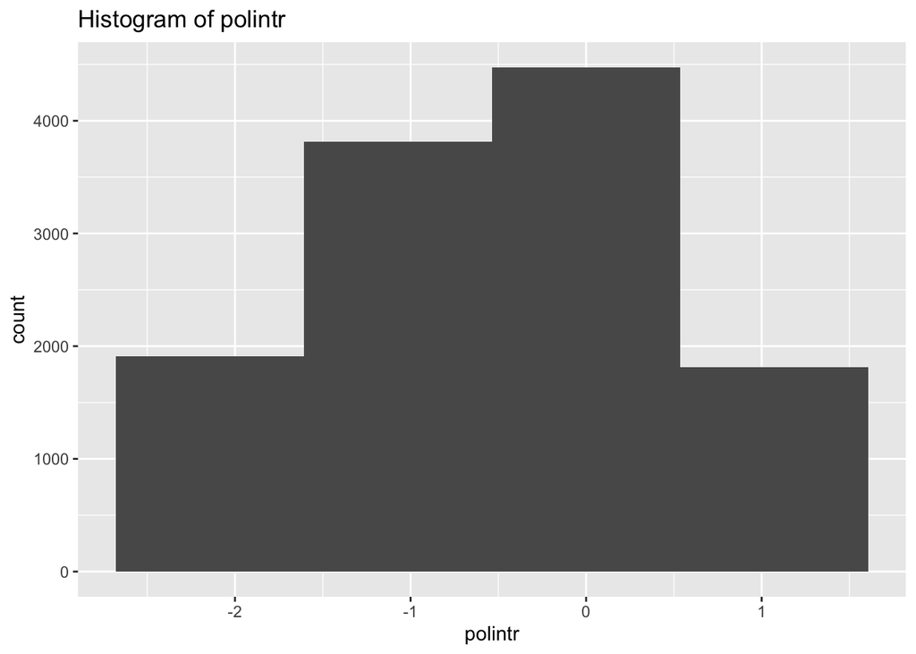

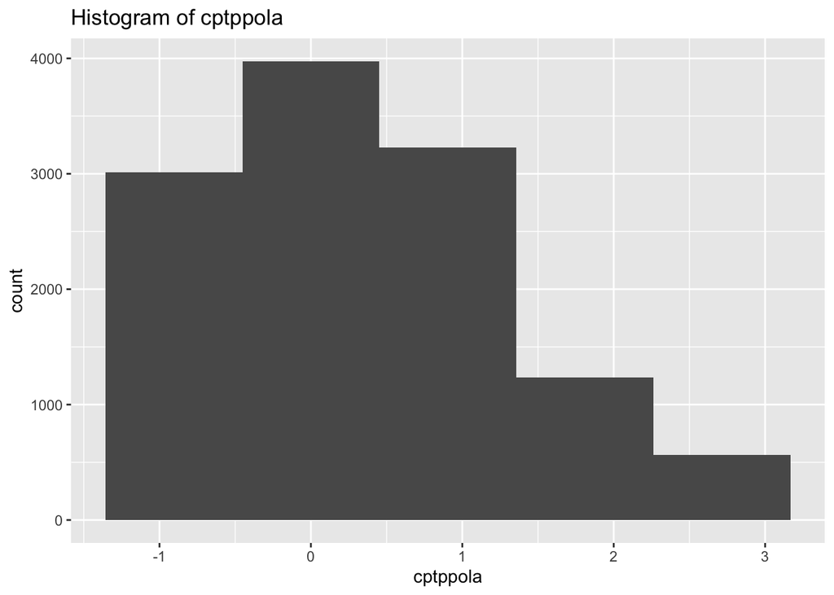

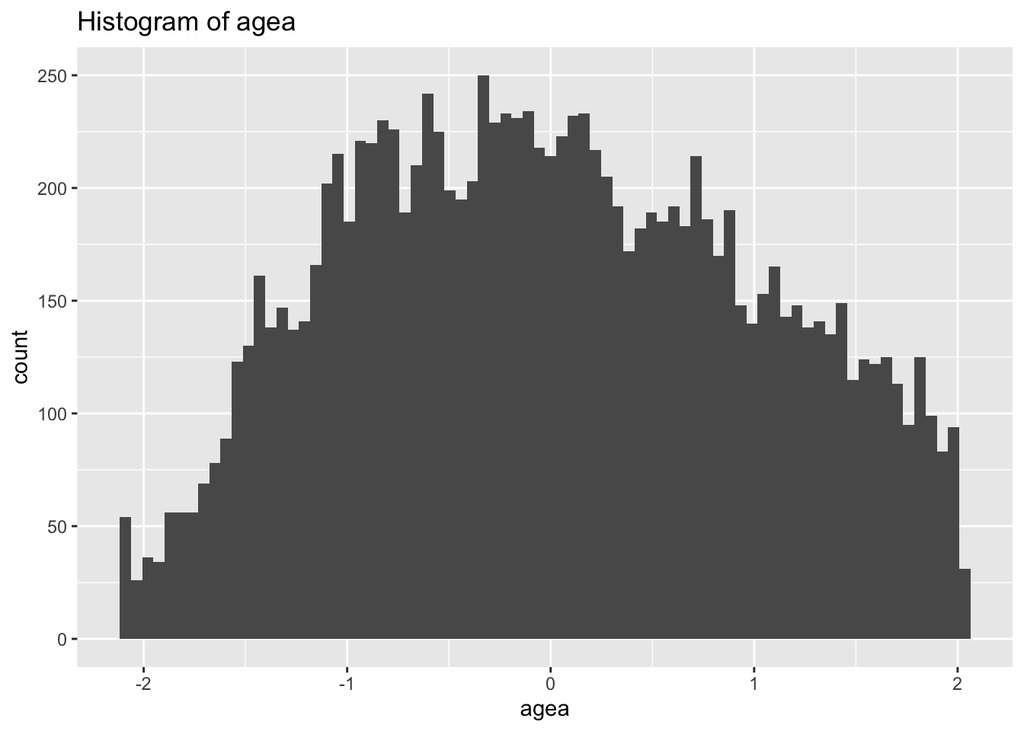

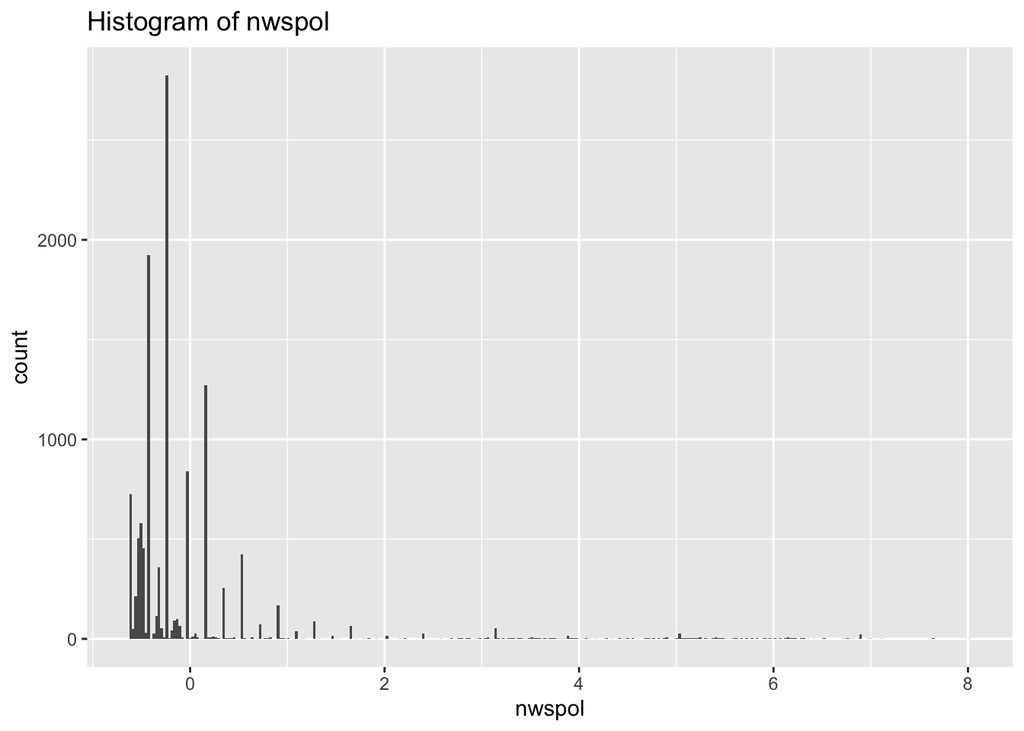

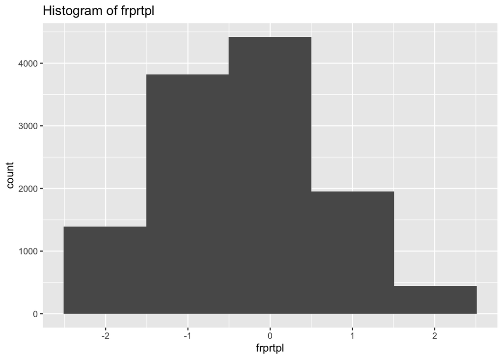

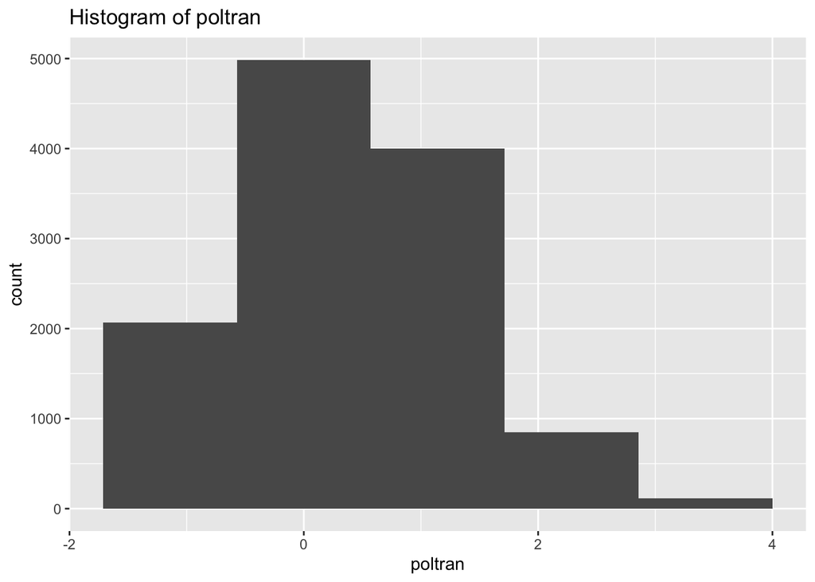

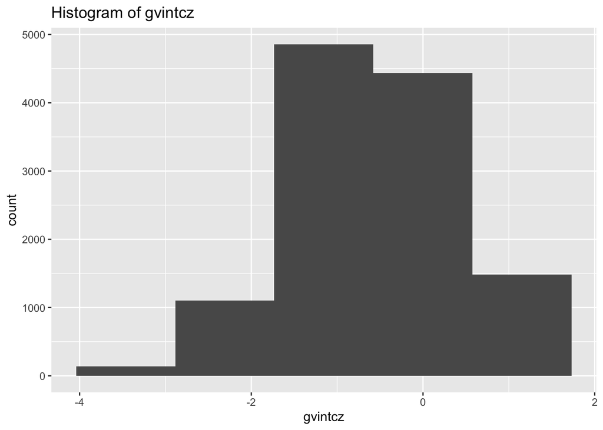

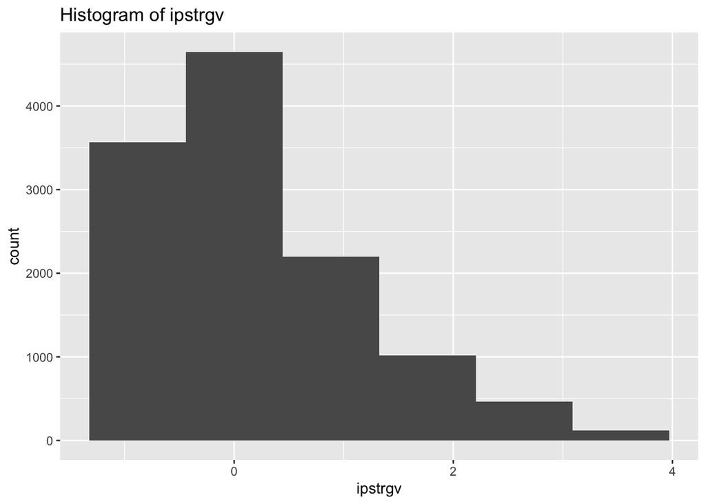

```r
# Plotting continuous variables
cont_vars <- c("polintr", "cptppola", "agea", "nwspol", "frprtpl", "poltran", "gvintcz", "ipstrgv")
for (var in cont_vars) {
  plot <- ggplot(filtered_data, aes(x = !!as.name(var))) +
    geom_histogram(bins = length(unique(filtered_data[[var]]))) +
    labs(title = paste("Histogram of", var))

  print(plot)
}
```

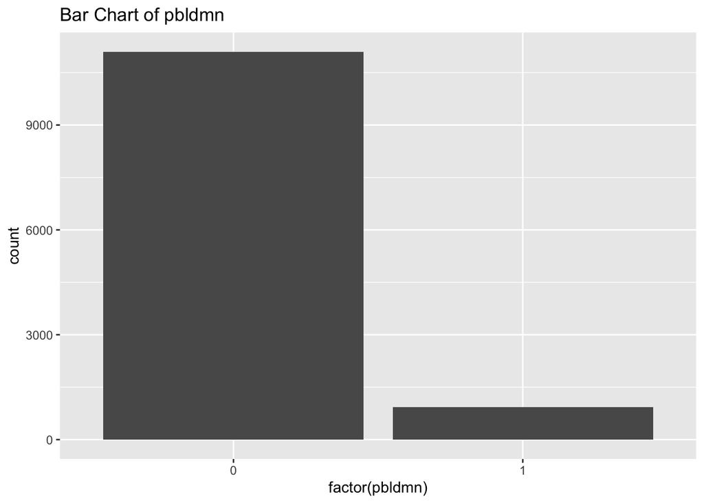

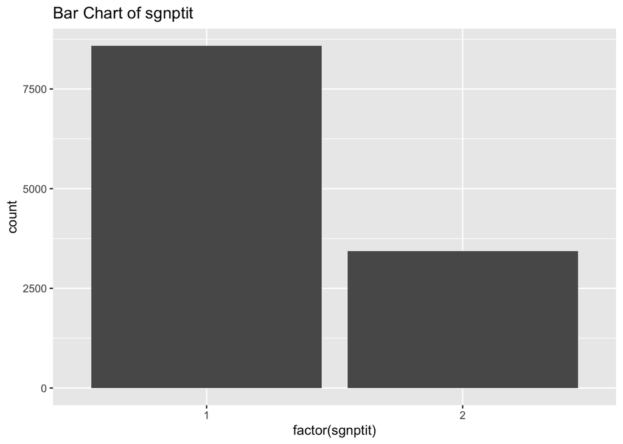

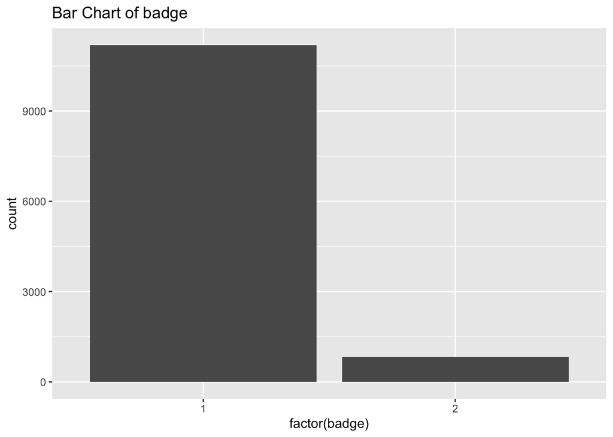

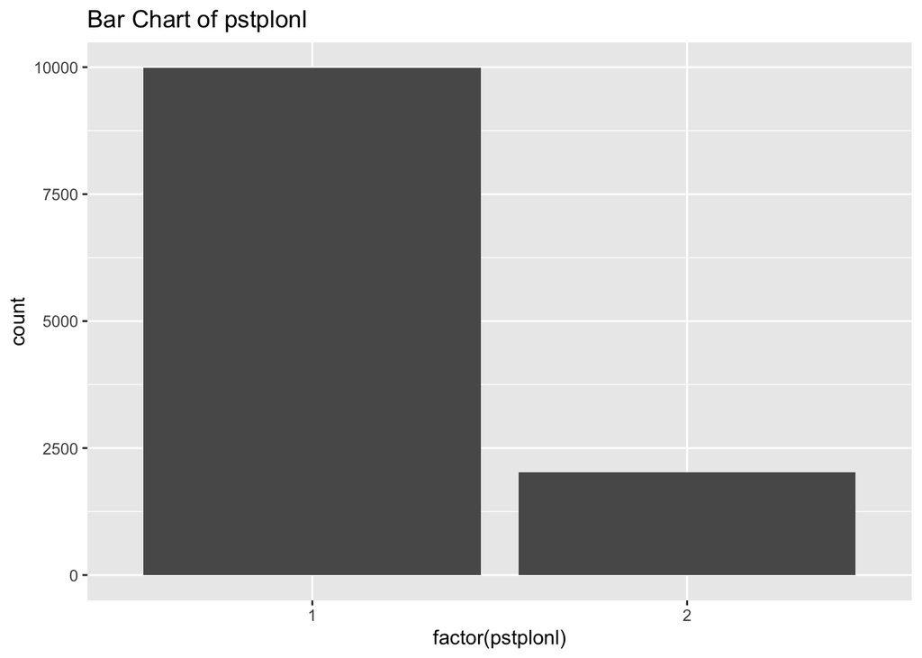

```r
# Plotting dichotomous variables.
dict_vars <- c("pbldmn", "sgnptit", "badge", "pstplonl")
for (var in dict_vars) {
  plot <- ggplot(filtered_data, aes(x = factor(!!as.name(var)))) +
    geom_bar() +
    labs(title = paste("Bar Chart of", var))

  print(plot)
}
```

```r
comment=NA
```

One interesting thing we can observe from the data, is that our outcome variable has considerable class imbalance. We will use up sampling later to see whether augmenting training data will lead to better results.

We create the model which contains our outcome variable and features.

```r
model1 <- formula("pbldmn ~ polintr + sgnptit + cptppola + badge + agea + nwspol + pstplonl + frprtpl + poltran + gvintcz + ipstrgv")
comment=NA
```

# 2. Testing Logistic Regression, Support Vector Machines and Naive Bayes models. 0 indicates not having been to a public demonstration in the last 12 months, while 1 indicates the opposite.

We select these three models as they can handle classification tasks. Below we briefly discuss all three.

- As we expect high multicollinearity among features, Logistic Regresion may not be the best model for this task. As well as this, it can often underfit data if the relationship between variables is complex, which is expected in this case.
- Support Vector Machines on the other hand are much more resilient towards multicollinearity. As well as this, they are well suited for modelling complex relationships. We expect SVM to perform relatively well for this task.
- Naive Bayes is also expected to perform well, as it deals better with multicollinearity. However, it assumes independence between features, which is an assumption that is difficult to justify in this case.

```r
#First we define and fit the model.
run_model <- function(fit_function, formula, train_data, test_data) {
    model <- fit_function(formula, data = train_data)

    # We predict on the test set.
    if ("svm" %in% class(model)) {
        prob_predictions <- attr(predict(model, newdata = test_data, probability = TRUE), "probabilities")[, 2]
    } else if ("naiveBayes" %in% class(model)) {
        prob_predictions <- predict(model, newdata = test_data, type = "raw")[, 2]
    } else {
        prob_predictions <- predict(model, newdata = test_data, type = "response")
    }

    test_predictions <- ifelse(prob_predictions > 0.5, 1, 0)

    # We create a confusion matrix.
    cm <- confusionMatrix(as.factor(test_predictions), as.factor(test_data$pbldmn), positive = "1")

    # We calculate the ROC AUC.
    roc_auc <- auc(roc(test_data$pbldmn, prob_predictions))

    # We extract metrics from confusion matrix.
    accuracy <- cm[["overall"]]["Accuracy"]
    precision <- cm[["byClass"]]["Precision"]
    recall <- cm[["byClass"]]["Recall"]
    f1 <- cm[["byClass"]]["F1"]

    # We return the metrics and confusion matrix as a list.
    return(list(
        confusion_matrix = cm$table,
        roc_auc = roc_auc,
        accuracy = accuracy,
        precision = precision,
        recall = recall,
        f1_score = f1
    ))
}


# We define three functions of the learning algorithms we use to pass as arguments to the loop function.

fit_logistic_regression <- function(formula, data) {
    glm(formula, data = data, family = "binomial")
}

fit_svm <- function(formula, data) {
    svm(formula, data = data, type = "C-classification", kernel = "radial", probability = TRUE)
}

fit_naive_bayes <- function(formula, data) {
    naiveBayes(formula, data = data)
}

# Due to the class imbalance in the outcome variables, we settle for only 5 folds for cross validation.
folds <- createFolds(filtered_data$pbldmn, k = 5)

fit_functions <- list(logistic_regression = fit_logistic_regression, svm = fit_svm, naive_bayes = fit_naive_bayes)

# We create an empty list that we will later populate with results.
results <- list()

# The model iterates through three learning algorithms and 5 different sets of data used for cross validation. (We use filtered_data for this, trainData and testData will be later used for the selected model).

for (fit_name in names(fit_functions)) {
    sum_cm <- matrix(0, nrow = 2, ncol = 2)
    sum_roc_auc <- sum_accuracy <- sum_precision <- sum_recall <- sum_f1 <- 0

    for (i in seq_along(folds)) {
        test_indices <- folds[[i]]
        train_indices <- unlist(folds[-i])

        train_data <- filtered_data[train_indices, ]
        test_data <- filtered_data[test_indices, ]

        metrics <- run_model(fit_functions[[fit_name]], model1, train_data, test_data)

        sum_cm <- sum_cm + metrics$confusion_matrix
        sum_roc_auc <- sum_roc_auc + metrics$roc_auc
        sum_accuracy <- sum_accuracy + as.numeric(metrics$accuracy)
        sum_precision <- sum_precision + as.numeric(metrics$precision)
        sum_recall <- sum_recall + as.numeric(metrics$recall)
        sum_f1 <- sum_f1 + as.numeric(metrics$f1_score)
    }

    # We divide everything by 5 as 5 sets of these metrics are summed up in these variables to find their average.
    avg_cm <- sum_cm / 5
    avg_roc_auc <- sum_roc_auc / 5
    avg_accuracy <- sum_accuracy / 5
    avg_precision <- sum_precision / 5
    avg_recall <- sum_recall / 5
    avg_f1 <- sum_f1 / 5

    results[[fit_name]] <- list(
        avg_confusion_matrix = avg_cm,
        avg_roc_auc = avg_roc_auc,
        avg_accuracy = avg_accuracy,
        avg_precision = avg_precision,
        avg_recall = avg_recall,
        avg_f1 = avg_f1
    )
}
#Finally we print out the results to compare three models between each other.
for (fit_name in names(results)) {
    cat(paste("Metrics for model:", fit_name, "\n"))
    cat(paste("Average Confusion Matrix:\n"))
    print(results[[fit_name]]$avg_confusion_matrix)
    cat(paste("Average ROC AUC:", results[[fit_name]]$avg_roc_auc, "\n"))
    cat(paste("Average Accuracy:", results[[fit_name]]$avg_accuracy, "\n"))
    cat(paste("Average Precision:", results[[fit_name]]$avg_precision, "\n"))
    cat(paste("Average Recall:", results[[fit_name]]$avg_recall, "\n"))
    cat(paste("Average F1 Score:", results[[fit_name]]$avg_f1, "\n\n"))
}
```

```
## Metrics for model: logistic_regression
## Average Confusion Matrix:
##           Reference
## Prediction      0      1
##          0 2194.6  148.6
##          1   24.4   36.2
## Average ROC AUC: 0.834668304833269
## Average Accuracy: 0.928031031648598
## Average Precision: 0.598604930490901
## Average Recall: 0.195836674370706
## Average F1 Score: 0.29407186999223
##
## Metrics for model: svm
## Average Confusion Matrix:
##           Reference
## Prediction      0      1
##          0 2204.6  159.8
##          1   14.4   25.0
## Average ROC AUC: 0.691632561784547
## Average Accuracy: 0.927531759731838
## Average Precision: 0.633297087469454
## Average Recall: 0.13459718132493
## Average F1 Score: 0.220691329218726
##
## Metrics for model: naive_bayes
## Average Confusion Matrix:
##           Reference
## Prediction      0      1
##          0 2086.2  107.4
##          1  132.8   77.4
## Average ROC AUC: 0.825205979604861
## Average Accuracy: 0.900076339683549
## Average Precision: 0.37290915485009
## Average Recall: 0.419166597412671
## Average F1 Score: 0.393654658996944
```

```r
comment=NA
```

To better understand the metrics we also plot them.

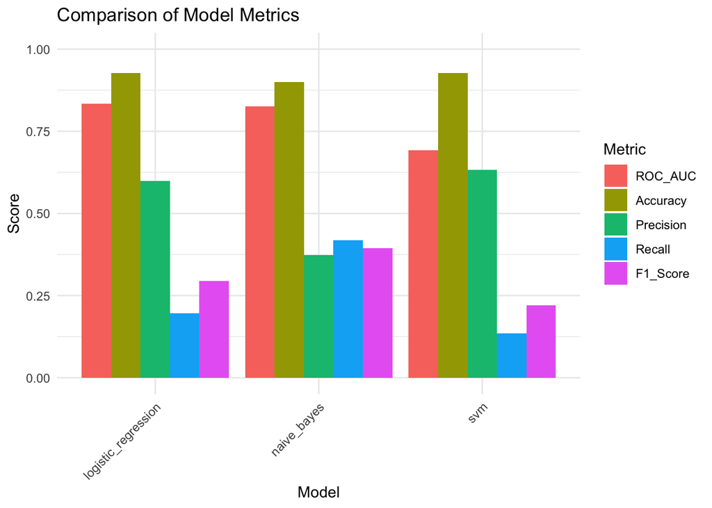

```r
#Extract metrics into a data frame for plotting.
metrics_data <- data.frame(
    Model = character(),
    ROC_AUC = numeric(),
    Accuracy = numeric(),
    Precision = numeric(),
    Recall = numeric(),
    F1_Score = numeric(),
    stringsAsFactors = FALSE
)
# Populate the data frame.
for (fit_name in names(results)) {
    metrics_data <- rbind(metrics_data, data.frame(
        Model = fit_name,
        ROC_AUC = as.numeric(results[[fit_name]]$avg_roc_auc),
        Accuracy = as.numeric(results[[fit_name]]$avg_accuracy),
        Precision = as.numeric(results[[fit_name]]$avg_precision),
        Recall = as.numeric(results[[fit_name]]$avg_recall),
        F1_Score = as.numeric(results[[fit_name]]$avg_f1),
        stringsAsFactors = FALSE
    ))
}
# Reshape data for plotting.
metrics_melted <- reshape2::melt(metrics_data, id.vars = "Model")

# Create a plot
p <- ggplot(metrics_melted, aes(x = Model, y = value, fill = variable)) +
    geom_bar(stat = "identity", position = "dodge") +
    theme_minimal() +
    labs(x = "Model", y = "Score", title = "Comparison of Model Metrics", fill = "Metric") +
    scale_y_continuous(limits = c(0, 1)) +
    theme(axis.text.x = element_text(angle = 45, hjust = 1))

# Show plot
print(p)
```

```r
comment=NA
```

# 3. We select and fit a Naive Bayes model and test it both on normal and upsampled data.

```r
run_single_model <- function(formula, train_data, test_data) {
    # Fit the Naive Bayes model
    model <- naiveBayes(formula, data = train_data)

    # We predict on the test set
    prob_predictions <- predict(model, newdata = test_data, type = "raw")[, 2]
    test_predictions <- ifelse(prob_predictions > 0.5, 1, 0)

    # We create a confusion matrix
    cm <- confusionMatrix(as.factor(test_predictions), as.factor(test_data$pbldmn), positive = "1")

    # We calculate the ROC AUC
    roc_auc <- auc(roc(test_data$pbldmn, prob_predictions))

    # We extract metrics from confusion matrix
    accuracy <- cm[["overall"]]["Accuracy"]
    precision <- cm[["byClass"]]["Precision"]
    recall <- cm[["byClass"]]["Recall"]
    f1 <- cm[["byClass"]]["F1"]

    # Return the metrics and confusion matrix as a list so we can use it later for comparisons.
    return(list(
        confusion_matrix = cm$table,
        roc_auc = round(as.numeric(roc_auc), 2),
        accuracy = round(as.numeric(accuracy), 2),
        precision = round(as.numeric(precision), 2),
        recall = round(as.numeric(recall), 2),
        f1_score = round(as.numeric(f1), 2)
    ))
}

# Train on normal data.
normal_metrics <- run_single_model(model1, trainData, testData)

# We upsample minority class, which is people who went on public demonstrations.
num_majority <- sum(trainData$pbldmn == 0)
num_minority <- sum(trainData$pbldmn == 1)
num_to_sample <- num_majority - num_minority
minority_samples <- trainData[trainData$pbldmn == 1, ]
oversampled_minority <- minority_samples[sample(nrow(minority_samples), num_to_sample, replace = TRUE), ]
upsampled_trainData <- rbind(trainData, oversampled_minority)

# Train on up sampled data
upsampled_metrics <- run_single_model(model1, upsampled_trainData, testData)

# Output confusion matrices of the normal and up sampled training data.
cat("Confusion Matrix for Normal Data:\n")
```

```
## Confusion Matrix for Normal Data:
```

```r
print(normal_metrics$confusion_matrix)
```

```
##           Reference
## Prediction    0    1
##          0 2082  120
##          1  121   81
```

```r
cat("\nConfusion Matrix for Upsampled Data:\n")
```

```
##
## Confusion Matrix for Upsampled Data:
```

```r
print(upsampled_metrics$confusion_matrix)
```

```
##           Reference
## Prediction    0    1
##          0 1734   55
##          1  469  146
```

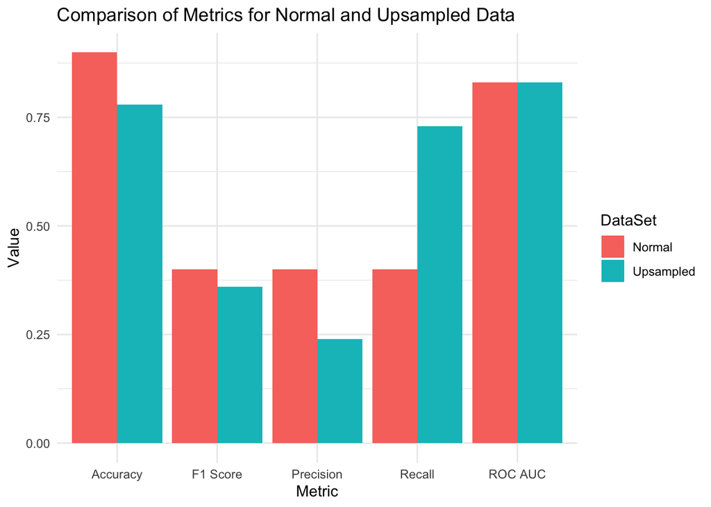

```r
# We combine the calculated metrics.
metrics_data <- data.frame(
    DataSet = rep(c("Normal", "Upsampled"), each = 5),
    Metric = rep(c("ROC AUC", "Accuracy", "Precision", "Recall", "F1 Score"), times = 2),
    Value = c(
        normal_metrics$roc_auc, normal_metrics$accuracy, normal_metrics$precision, normal_metrics$recall, normal_metrics$f1_score,
        upsampled_metrics$roc_auc, upsampled_metrics$accuracy, upsampled_metrics$precision, upsampled_metrics$recall, upsampled_metrics$f1_score
    )
)

# We plot the metrics.
ggplot(metrics_data, aes(x = Metric, y = Value, fill = DataSet)) +
    geom_bar(stat = "identity", position = "dodge") +
    labs(title = "Comparison of Metrics for Normal and Upsampled Data", y = "Value") +
    theme_minimal()
```

```r
comment=NA
```

Choosing between upsampled and normal training set is difficult. However, we recommend the upsampled training set. Even though false positives increase, as evident both from confusion matrix and the plot, model better ‘catches’ actual cases when people did go to public demonstrations in the last 12 months (outcome 1). As such, it is tempting to use upsampled data for training instead.

We used ChatGPT for the following purposes:

- Organizing code into functions and making it more modular
- Dealing with errors in code
- Simplifying the code